```python
import numpy as np
```

# Section A

### 1a. List down any 2 differences between list and tuple.

- Lists are mutable, meaning their elements can be changed after creation, while tuples are immutable and cannot be changed once created.
- Lists use more memory and have slightly slower performance compared to tuples, which are lighter and faster due to immutability.

### 1b. What is Seaborn's main function in data visualization, and how does it enhance the appearance of statistical plots?

- Seaborn is a Python visualization library based on Matplotlib that simplifies the creation of informative and attractive statistical graphics.
- It enhances appearance by providing high-level interfaces for drawing attractive statistical graphics with default themes and color palettes that improve plot readability.

### 1c. What is the difference between append() and extend() methods?

- append() adds its argument as a single element to the end of the list, increasing the list length by 1.
- extend() iterates over its argument adding each element to the list, extending the list by the number of elements in the argument.

### 1d. What are *args and kwargs in Python functions?

- *args is used to pass a variable number of non-keyword arguments to a function as a tuple.
- **kwargs allows passing a variable number of keyword arguments to a function as a dictionary.

### 1e. What are different approaches for typecasting in Python?

- Using built-in functions like int(), float(), str(), list(), tuple(), etc., to convert one data type to another.
- Using constructor methods of classes to perform typecasting.
- Implicit casting by Python interpreter where applicable, like int to float during operations.

### 2a. How to merge dataframes in pandas?

To merge DataFrames in pandas, use the merge() function. It is similar to SQL joins and combines rows from two DataFrames based on a common key or keys.

Example:

python import pandas as pd

Assume df1 and df2 are two DataFrames with a common column 'id'

### 2b. Define significant features of Numpy library.

- NumPy provides high-performance multidimensional array objects called ndarray.
- It allows vectorized operations (element-wise computations) on arrays, enabling efficient mathematical computations.
- NumPy supports broadcasting, linear algebra operations, random number generation, and integration with C/C++.

### 2c. How to rank the rows of DataFrame?

Use the rank() method of pandas DataFrame to add a ranking column based on values of a specific column.

Example:

### 2d. What are map and reduce functions in Python?

- map: Applies a function to every item in an iterable (like a list) and returns a map object (can be converted to a list).

python result = list(map(lambda x: x*2, [1, 2, 3])) # [2, 4, 6]

- reduce: Repeatedly applies a binary function to the items of an iterable, reducing it to a single cumulative value. It is in the functools module.

### 2e. Describe the characteristics and purpose of dictionaries in Python.

- Dictionaries are unordered, mutable collections of key-value pairs.
- Keys must be unique and immutable (like strings, numbers, or tuples).
- Values can be of any data type and can be duplicated.
- Dictionaries are optimized for retrieving, adding, or modifying values based on a unique key.
- Primary purpose: fast lookups and association of related data (e.g., word-definition, name-phone number).

```python
# 2a. How to merge dataframes in pandas?

import pandas as pd

def merge_dataframes(df1, df2, on_column, how='inner'):
    """
    Merge two dataframes on a given column using specified method.

    Parameters:
        df1 (pd.DataFrame): First dataframe
        df2 (pd.DataFrame): Second dataframe
        on_column (str): Column name to merge on
        how (str): Type of merge - 'inner', 'outer', 'left', 'right'

    Returns:
        pd.DataFrame: Merged dataframe
    """
    merged_df = pd.merge(df1, df2, on=on_column, how=how)
    return merged_df


# 2b. Define significant features of Numpy library.

numpy_features = """
- Provides support for large, multi-dimensional arrays and matrices.
- Offers a large collection of high-level mathematical functions to operate on these arrays.
- Enables efficient numerical computation with broadcasting, vectorization, and integrated C and Fortran code.
"""

# 2c. How to rank the rows in pandas dataframe based on a specific column?

def rank_dataframe(df, rank_column, ascending=True):
    """
    Rank rows of a dataframe based on specified column.

    Parameters:
        df (pd.DataFrame): Input dataframe
        rank_column (str): Column based on which ranking is to be done
        ascending (bool): Rank in ascending order if True, else descending

    Returns:
        pd.DataFrame: Dataframe with an added 'Rank' column
    """
    df['Rank'] = df[rank_column].rank(ascending=ascending)
    return df


# 2d. What are different types of joins in pandas?

join_types = """
- inner: Returns intersection of keys from both dataframes.
- outer: Returns union of keys, with NaN for missing matches.
- left: Returns keys from left dataframe with matched keys from right.
- right: Returns keys from right dataframe with matched keys from left.
"""

# 2e. Basic syntax of reading a csv file in pandas and_display the first 5 records

def read_csv_file(file_path):
    """
    Read a CSV file and return the first 5 rows.

    Parameters:
        file_path (str): Path to CSV file

    Returns:
        pd.DataFrame: First 5 rows of the CSV file
    """
    df = pd.read_csv(file_path)
    return df.head()
```

# Section B

### Question 3a.i

i) You are working on a project to develop a simple online shopping application. You need to implement various data structures in Python to manage the shopping cart, product inventory, and user information efficiently.

You have been given a list of products with their names and prices. Write a Python function named calculate_total_cost that takes a list of products and their corresponding quantities in the shopping cart and returns the total cost of the items.

```python
def calculate_total_cost(products, quantities):
    """
    Calculate the total cost of items in the shopping cart.

    Parameters:
    products (list of tuples): List containing tuples of (product_name, price)
    quantities (list of int): List containing corresponding quantities for each product

    Returns:
    float: Total cost of all products with quantities
    """
    total_cost = 0
    for (product, price), quantity in zip(products, quantities):
        total_cost += price * quantity
    return total_cost

# Example Usage
products = [('Laptop', 50000), ('Mouse', 500), ('USB Cable', 200)]
quantities = [1, 2, 3]

total = calculate_total_cost(products, quantities)
print("Total Cost:", total)
```

```
Total Cost: 51600
```

```python
def calculate_total_cost(products, quantities):
    total = 0
    for i in range(len(products)):
        name, price = products[i]
        total += price * quantities[i]
    return total

products = [("Laptop", 50000), ("Mouse", 500)]
quantities = [1, 2]
print(calculate_total_cost(products, quantities))  # 51000
```

```
51000
```

```python
def calculate_total_cost(products, quantities):
  total = 0
  for i in range(len(products)):
    name, price = products[0]
    total += quantities[i] * price
    return total

products = {
  'Laptop': 50000,
  'mouse': 1000
}

quantities = [ 1, 3]

calculate_total_cost(products, quantities)
```

[output not shown]

### 3(a)(ii) Product inventory dictionary

```python
product_inventory = {
    "Laptop": 10,
    "Mouse": 50,
    "Keyboard": 30
}
```

### 3(a)(iii) Update inventory

```python
def update_inventory(product_inventory, new_shipment):
    for product, qty in new_shipment.items():
        product_inventory[product] = product_inventory.get(product, 0) + qty
    return product_inventory

shipment = {"Laptop": 5, "Monitor": 10}
print(update_inventory(product_inventory, shipment))
```

```
{'Laptop': 15, 'Mouse': 50, 'Keyboard': 30, 'Monitor': 10}
```

### 3(a)(iv) Apply discount

```python
def apply_discount(product_prices, discount_dict):
    for product, new_price in discount_dict.items():
        if product in product_prices:
            product_prices[product] = new_price
    return product_prices

prices = {"Laptop": 50000, "Mouse": 500}
discounts = {"Laptop": 45000}
print(apply_discount(prices, discounts))  # {'Laptop': 45000, 'Mouse': 500}
```

```
{'Laptop': 45000, 'Mouse': 500}
```

### 3(b) Scientific Calculator

```python
import math

def calculator():
    print("Choose operation: 1.Arithmetic 2.Trigonometric 3.Logarithmic")
    choice = int(input("Enter choice: "))

    if choice == 1:
        a, b = map(float, input("Enter two numbers: ").split())
        print("Sum:", a+b, "Diff:", a-b, "Prod:", a*b, "Div:", a/b)
    elif choice == 2:
        angle = float(input("Enter angle in radians: "))
        print("sin:", math.sin(angle), "cos:", math.cos(angle), "tan:", math.tan(angle))
    elif choice == 3:
        num = float(input("Enter number: "))
        print("log:", math.log(num), "log10:", math.log10(num))

calculator()
```

```
Choose operation: 1.Arithmetic 2.Trigonometric 3.Logarithmic
Sum: 68.0 Diff: -22.0 Prod: 1035.0 Div: 0.5111111111111111
```

### 3(c) Reverse words

```python
def reverse_words(sentence):
    return " ".join(sentence.split()[::-1])

print(reverse_words("Python for Data Science"))  # "Science Data for Python"
```

```
Science Data for Python
```

### 3(d) Find special codes

```python
def find_special_codes(message):
    words = message.split()
    return [w for w in words if w.isalnum()]

msg = "abc123 @#$ xyz789"
print(find_special_codes(msg))  # ['abc123', 'xyz789']
```

```
['abc123', 'xyz789']
```

# Section C

### 4(a) Ecommerce Purchases dataset

```python
import pandas as pd

df = pd.read_csv("Ecommerce Purchases1.csv")

# I. Top 5 job titles
print(df['Job'].value_counts().head(5))

# II. American Express & purchase > 95
print(len(df[(df['CC Provider']=='American Express') & (df['Purchase Price']>95)]))

# III. Credit card expiring in 2025
print(len(df[df['CC Exp Date'].apply(lambda x: x.split('/')[1]=='25')]))

# IV. Top 5 email providers
df['Email Provider'] = df['Email'].apply(lambda x: x.split('@')[1])
print(df['Email Provider'].value_counts().head(5))
df['Email Provider'].value_counts().head(5).plot(kind='bar')

# V. Purchase from Lot "90 WT"
print(df[df['Lot']=='90 WT']['Purchase Price'])

# VI. Email for CC number
print(df[df['CC Number']==4926535242672853]['Email'])
```

[output not shown]

[output cut: 9 more lines]

[output not shown]

### 4(b) Athlete Events + Regions dataset

```
            ID                           Name Sex   Age  Height  Weight  \
5078      2894         Derek Swithin Allhusen   M  54.0   180.0    71.0
7961      4404             Johan August Anker   M  56.0     NaN     NaN
13394     7272     Nikolaus "Klaus" Balkenhol   M  52.0   178.0    83.0
13396     7272     Nikolaus "Klaus" Balkenhol   M  56.0   178.0    83.0
24897    13033  Gustaf Adolf Boltenstern, Jr.   M  52.0     NaN     NaN
...        ...                            ...  ..   ...     ...     ...
261102  130662        Robert W. Williams, Jr.   M  63.0     NaN     NaN
261671  130936                  Walter Winans   M  56.0     NaN     NaN
261675  130936                  Walter Winans   M  60.0     NaN     NaN
262865  131533       Emily Woodruff (Smiley-)   F  58.0     NaN     NaN
266293  133226       Mahonri Mackintosh Young   M  54.0     NaN     NaN

                      Team  NOC        Games  Year  Season         City  \
5078         Great Britain  GBR  1968 Summer  1968  Summer  Mexico City
```

[output cut: 98 more lines]

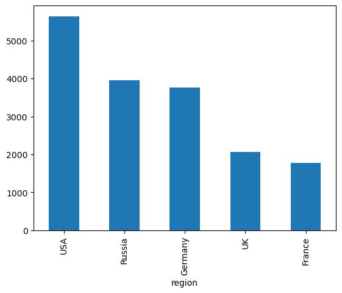

```python
athletes = pd.read_csv("athlete_events.csv")
regions = pd.read_csv("regions.csv")

# 1. Merge
merged = athletes.merge(regions, on="NOC", how="left")

# 2. Age distribution of gold medalists
gold = merged[(merged['Medal']=='Gold')]
gold['Age'].hist()

# 3. Gold medalists age > 50
print(gold[gold['Age']>50])

# 4. Women who played in Summer
print(merged[(merged['Sex']=='F') & (merged['Season']=='Summer')])

# 5. Top 5 countries with most medals
medals = merged.groupby('region')['Medal'].count().sort_values(ascending=False).head(5)
print(medals)
medals.plot(kind='bar')
```

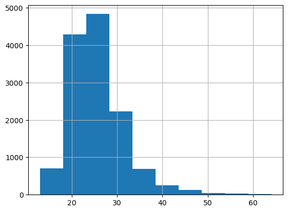

```python
gold['Age'].hist()
```